# Apuntes de percepción visual

# Práctica 1: Efectos cromáticos

## Conceptos previos

Cuando nos exponemos a un estímulo, éste tiene multitud de propiedades físicas. En esta práctica nos vamos a centrar en aquellas que tiene que ver con cómo percibimos el color. El factor más importnate para describir el color es la longitud de onda ($\lambda$) de la luz. Es importante conocer cómo reacciona un objeto a la exposición de una misma luz:

1. **Reflexión selectiva**: Indica la cantidad relativa de longitudes de onda que una superficie refleja dada una luz blanca (incluye todas las longitudes de onda del espectro visible). Por ejemplo, un tomate absorbería longitudes de onda cortas y medias (azules y verdes), mientras que reflejaría ondas de longitud larga (rojo).
2. **Curva de reflectancia**: Indica la cantidad absoluta de longitudes de onda reflejadas. En la siguiente figura se puede ver cómo el área bajo la curva que describe el color azul más claro es mayor que la del azul más oscuro.

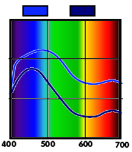

La combinación de ambas caracteristicas sobre cómo reaccionan diferentes superficies a la luz son suficientes para describir la percepción del color en diferentes sistemas. En concreto, nosotros vamos a definir las características del color mediante el sistema HSV. Dentro de esta categorización encontramos las siguientes dimensiones:

1. **Matiz**: Se relaciona con cantidad relativa de las longitudes de onda reflejadas. Es lo que comunente denominamos como color.
2. **Luminosidad o intensidad (también llamado valor)**: Hace referencia a la cantidad absoluta de luz que refleja una superficie en una determinada direción o ángulo por unidad de superficie. En el SMI se mide en $cd/m^{2}$ (candelas por metro cuadrado). Este es un factor de vital importancia en determinadas situaciones. Por ejemplo, las empresas de telefonía móvil han logrado superar en los últimos dispositivos la barrera de las 300 $cd/m^{2}$ optimizando el consumo de batería para favorecer la visibilidad bajo la luz solar. Dentro del espectro electromagnético estaría indicado por la amplitud de onda. Por su parte, su correspondencia psicofísica sería el **brillo**, que estaría definido como la sensación percibida de la intensidad lumínica.
3. **Saturación**: Hace referencia a la proporción de blanco/negro con respecto al matiz cromático puro. Es decir, cuando hay una alta intensidad en una longitud de onda (o rango de longitudes de onda), el color será muy saturado. Mientras que si la intensidad está repartida uniformemente a través del espectro electromgnético se dirá que está poco saturado.

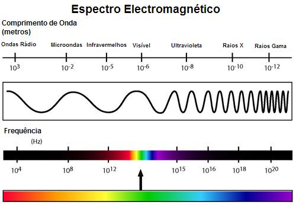

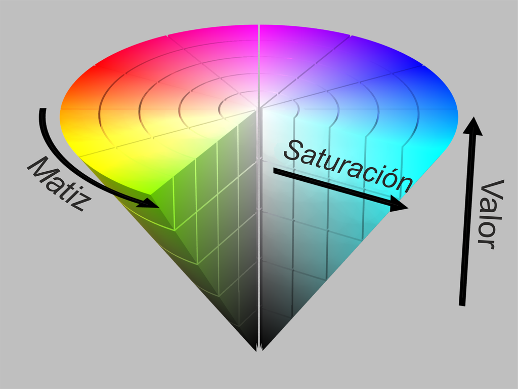

## Efecto Abney

Cambio en el **matiz percibido** inducido por cambios en la pureza cromática (saturación). No es debido ni a cambios en la longitud de onda ni en el brillo.

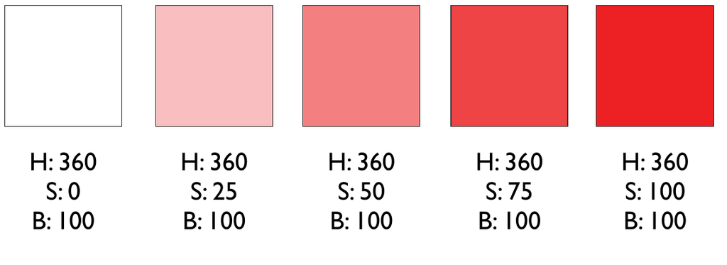

Tanto el Hue como la luminosidad se mantienen constantes, mientras que lo que varía es la saturación. Esto produce un cambio en el matiz percibido.

## Efecto Bezold-Brücke

Cambio en el matiz percibido inducido por cambios en el brillo. NO es debido ni a cambios en la longitud de onda ni en la saturación.

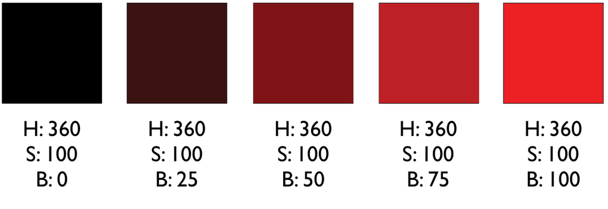

Tanto el Hue como la saturación se mantienen constantes, mientras que lo que varía es la luminosidad. Esto produce un cambio en el matiz percibido.

## Efecto Helmholtz-Kohlrausch

Un estímulo cromático (con matiz), es percibido como más brillante que un estimulo acromático aunque ambos tengan la misma luminancia.

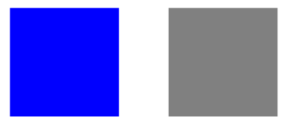

## Práctica 1: Efecto Helmholtz-Kohlsrauch

Este efecto es descrito como la sensación de que un estímulo cromático (con matiz), es percibido como más brillante que un estimulo acromático aunque ambos tengan la misma luminancia.

**Estímulación física:**

$$\begin{equation}
\label{HK_F}
\ Lum_{Crom} = Lum_{Acrom}
\end{equation}$$

**Sensación perceptual:**

$$\begin{equation}
\label{HK_S}
\ Brillo_{Crom} > Brillo_{Acrom}
\end{equation}$$

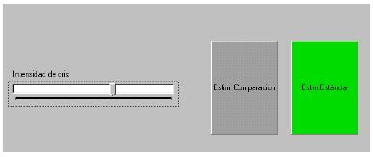

Para poner a prueba este efecto, pedimos a los participantes ajustar la luminancia del estímulo acromático (estímulo test o de comparación) para hacer coincidir en brillo con el estímulo cromático (estímulo estándar o de referencia).

Estamos también interesados en saber si hay algún matiz atiz que se percibe como más brillante que otro, por lo tanto creamos un experimento con la siguiente metodología.

**Variables**

Como no somos procesadores de información infalibles y nuestra respuesta tiene cierta variabilidad o error, hemos de realizar cada combinación de condiciones varias veces. En este caso, para que el experimento sea corto hemos introducido únicamente 3 repeticiones. Por lo tanto: 4 matices * 10 luminancias del estímulo cromático * 3 repeticiones dan un total de 120 ensayos o trials.

- Hipótesis
- Dado el mismo brillo percibido

$$\begin{equation}
\label{HK_1}
\ Brillo_{Crom} = Brillo_{Acrom}
\end{equation}$$

- La luminancia del estímulo acromático será mayor que la del estímulo cromático

$$\begin{equation}
\label{HK_2}
\ Lum_{Crom} < Lum_{Acrom}
\end{equation}$$